# Homework 7

## Problem #1: Estimating Quantiles (8 pts; 2pts each)

There are 9 algorithms in R to estimate population quantiles. Type `?quantile` to read about them. Here we will investigate the variance of some of these estimators. To use the quantile function you use the syntax `quantile(vector, probs, type)`. For example if you have data in a vector called `sampleData` and you wish to estimate the 80th percentile using algorithm 7 (the default), you use `quantile(sampleData, .80, type=7)`

Suppose we’re interested in the 95th percentile for $X$, and we know that $X$ follows a uniform distribution. We want to randomly sample $n=30$ values and estimate the 95th percentile. Using MC simulation estimate the following:

1. Which quantile algorithm (4 through 9) has the smallest absolute bias ($|\hat{\theta}-\theta|$)? *Hint: you can use $unif(0,1)$ for the purposes of this estimation, as your answer won’t depend on the upper and lower bounds chosen.*

```r
set.seed(123)
n_samples <- 30
num_simulations <- 10000
quantile_index <- 0.95

# Generate random samples from U(0, 1)
samples <- matrix(runif(num_simulations * n_samples), ncol = n_samples)

# True 95th percentile of U(0, 1)
true_percentile <- quantile_index

# Quantile algorithms 4 through 9
quantile_algorithms <- 4:9
absolute_biases <- numeric(length(quantile_algorithms))

for (i in seq_along(quantile_algorithms)) {
  algorithm <- quantile_algorithms[i]
  estimated_percentiles <- apply(samples, 1, quantile, probs = quantile_index, type = algorithm)
  cat("Mean of estimated percatiles:  ", mean(estimated_percentiles), ",  ")
  absolute_bias <- mean(abs(estimated_percentiles - true_percentile))

  absolute_biases[i] <- absolute_bias
  cat(sprintf("Algorithm %d: absolute_bias = %f\n", algorithm, absolute_biases[i]))
}
```

```
## Mean of estimated percatiles:   0.9196949 ,  Algorithm 4: absolute_bias = 0.039568
## Mean of estimated percatiles:   0.9359678 ,  Algorithm 5: absolute_bias = 0.032861
## Mean of estimated percatiles:   0.9503398 ,  Algorithm 6: absolute_bias = 0.026800
## Mean of estimated percatiles:   0.9213222 ,  Algorithm 7: absolute_bias = 0.038492
## Mean of estimated percatiles:   0.9407585 ,  Algorithm 8: absolute_bias = 0.030263
## Mean of estimated percatiles:   0.9395608 ,  Algorithm 9: absolute_bias = 0.030868
```

```r
# Find the algorithm with the smallest absolute bias
min_bias_index <- which.min(absolute_biases)
best_algorithm <- quantile_algorithms[min_bias_index]

cat(sprintf("Among quantile algorithms 4-9,  %d has the smallest absolute bias: %f\n", best_algorithm, absolute_biases[min_bias_index]))
```

```
## Among quantile algorithms 4-9,  6 has the smallest absolute bias: 0.026800
```

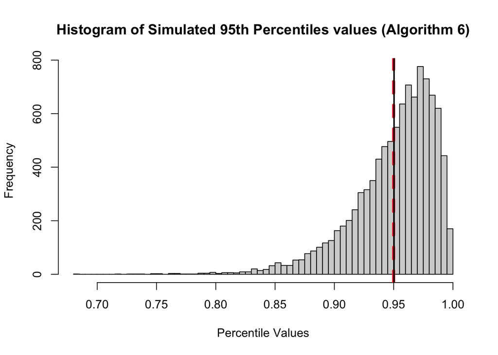

```r
# Plot the histogram of the simulated distributions of percentiles for the best algorithm
best_algorithm <- quantile_algorithms[which.min(absolute_biases)]
best_percentiles <- apply(samples, 1, quantile, probs = quantile_index, type = best_algorithm)
#best_percentiles
hist(best_percentiles, breaks = 50, main = sprintf("Histogram of Simulated 95th Percentiles values (Algorithm %d)", best_algorithm), xlab = "Percentile Values")
abline(v = true_percentile, col = "red", lty=2, lwd = 4)
#abline(v = mean(quantile_estimates[, best_algorithm]), col = "black", lwd = 2)
abline(v = mean(best_percentiles), col = "black", lwd = 2)
```

2. Which quantile algorithm (4 through 9) has the smallest variance?

```r
set.seed(123)
n_samples <- 30
num_simulations <- 10000
quantile_index <- 0.95

# Generate random samples from U(0, 1)
samples <- matrix(runif(num_simulations * n_samples), ncol = n_samples)

# Quantile algorithms 4 through 9
quantile_algorithms <- 4:9
variances <- numeric(length(quantile_algorithms))

for (i in seq_along(quantile_algorithms)) {
  algorithm <- quantile_algorithms[i]
  estimated_percentiles <- apply(samples, 1, quantile, probs = quantile_index, type = algorithm)
  variances[i] <- var(estimated_percentiles)

  cat(sprintf("Algorithm %d: Variance = %f\n", algorithm, variances[i]))
}
```

```
## Algorithm 4: Variance = 0.002071
## Algorithm 5: Variance = 0.001860
## Algorithm 6: Variance = 0.001219
## Algorithm 7: Variance = 0.002028
## Algorithm 8: Variance = 0.001603
## Algorithm 9: Variance = 0.001663
```

```r
# Find the algorithm with the smallest variance
min_variance_index <- which.min(variances)
best_algorithm_variance <- quantile_algorithms[min_variance_index]

cat(sprintf("Quantile algorithm %d has the smallest variance: %f\n", best_algorithm_variance, variances[min_variance_index]))
```

```
## Quantile algorithm 6 has the smallest variance: 0.001219
```

3. Which method is best for estimating the 95th percentile from a uniform distribution? Justify your answer.

```r
set.seed(123)
n_samples <- 30
num_simulations <- 10000
quantile_index <- 0.95

# Generate random samples from U(0, 1)
samples <- matrix(rnorm(num_simulations * n_samples), ncol = n_samples)

# True 95th percentile of U(0, 1)
true_percentile <- qnorm(quantile_index,0,1)

# Quantile algorithms 4 through 9
quantile_algorithms <- 4:9
absolute_biases <- numeric(length(quantile_algorithms))

for (i in seq_along(quantile_algorithms)) {
  algorithm <- quantile_algorithms[i]
  estimated_percentiles <- apply(samples, 1, quantile, probs = quantile_index, type = algorithm)
  cat("Mean of estimated percatiles:  ", mean(estimated_percentiles), ",  ")
  absolute_bias <- mean(abs(estimated_percentiles - true_percentile))

  absolute_biases[i] <- absolute_bias
  cat(sprintf("Algorithm %d: absolute_bias = %f\n", algorithm, absolute_biases[i]))
}
```

```
## Mean of estimated percatiles:   1.495353 ,  Algorithm 4: absolute_bias = 0.288390
## Mean of estimated percatiles:   1.622662 ,  Algorithm 5: absolute_bias = 0.291661
## Mean of estimated percatiles:   1.814361 ,  Algorithm 6: absolute_bias = 0.328845
## Mean of estimated percatiles:   1.508083 ,  Algorithm 7: absolute_bias = 0.285698
## Mean of estimated percatiles:   1.686561 ,  Algorithm 8: absolute_bias = 0.288006
## Mean of estimated percatiles:   1.670586 ,  Algorithm 9: absolute_bias = 0.287251
```

```r
# Find the algorithm with the smallest absolute bias
min_bias_index <- which.min(absolute_biases)
best_algorithm <- quantile_algorithms[min_bias_index]

cat(sprintf("Among quantile algorithms 4-9,  %d has the smallest absolute bias: %f\n", best_algorithm, absolute_biases[min_bias_index]))
```

```
## Among quantile algorithms 4-9,  7 has the smallest absolute bias: 0.285698
```

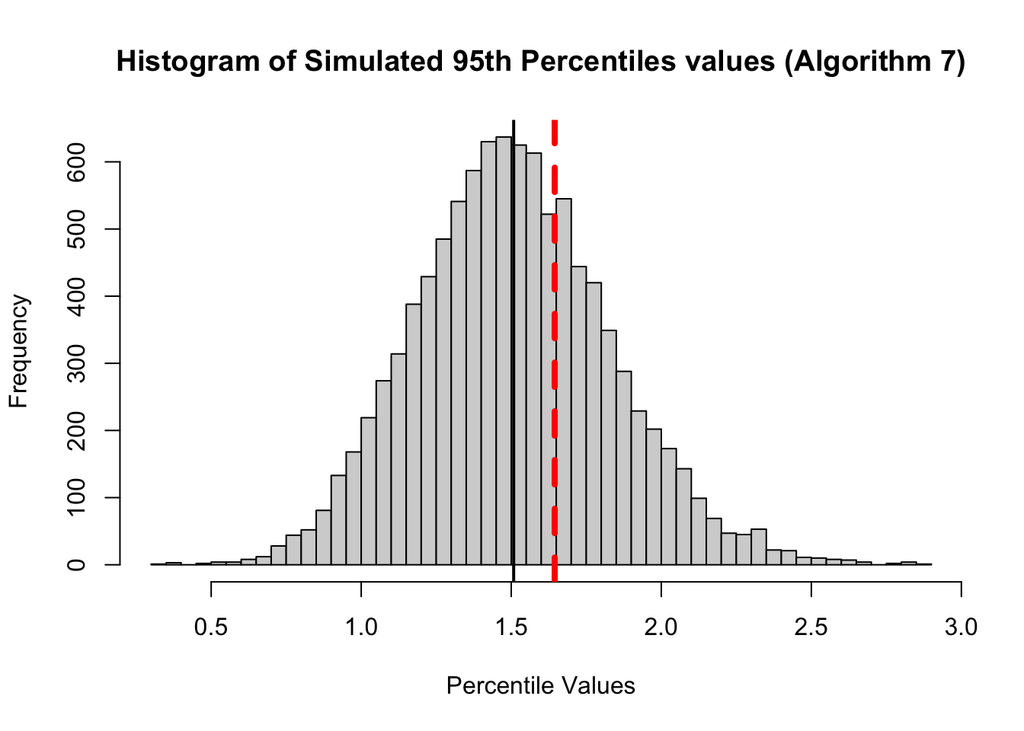

```r
# Plot the histogram of the simulated distributions of percentiles for the best algorithm
best_algorithm <- quantile_algorithms[which.min(absolute_biases)]
best_percentiles <- apply(samples, 1, quantile, probs = quantile_index, type = best_algorithm)
#best_percentiles
hist(best_percentiles, breaks = 50, main = sprintf("Histogram of Simulated 95th Percentiles values (Algorithm %d)", best_algorithm), xlab = "Percentile Values")
abline(v = true_percentile, col = "red", lty=2, lwd = 4)
#abline(v = mean(quantile_estimates[, best_algorithm]), col = "black", lwd = 2)
abline(v = mean(best_percentiles), col = "black", lwd = 2)
```

```r
set.seed(123)
n_samples <- 30
num_simulations <- 10000
quantile_index <- 0.95

# Generate random samples from U(0, 1)
samples <- matrix(rnorm(num_simulations * n_samples), ncol = n_samples)

# Quantile algorithms 4 through 9
quantile_algorithms <- 4:9
variances <- numeric(length(quantile_algorithms))

for (i in seq_along(quantile_algorithms)) {
  algorithm <- quantile_algorithms[i]
  estimated_percentiles <- apply(samples, 1, quantile, probs = quantile_index, type = algorithm)
  variances[i] <- var(estimated_percentiles)

  cat(sprintf("Algorithm %d: Variance = %f\n", algorithm, variances[i]))
}
```

```
## Algorithm 4: Variance = 0.105638
## Algorithm 5: Variance = 0.135932
## Algorithm 6: Variance = 0.150025
## Algorithm 7: Variance = 0.107411
## Algorithm 8: Variance = 0.133937
## Algorithm 9: Variance = 0.133808
```

```r
# Find the algorithm with the smallest variance
min_variance_index <- which.min(variances)
best_algorithm_variance <- quantile_algorithms[min_variance_index]

cat(sprintf("Quantile algorithm %d has the smallest variance: %f\n", best_algorithm_variance, variances[min_variance_index]))
```

```
## Quantile algorithm 4 has the smallest variance: 0.105638
```

> When it comes to variances, both with and without seed, I got algorithm 4 as the best.

## Problem #2: Estimating a Geometric $p$ (6 pts; 2 pts each)

1. Use the method of moments to come up with an estimator for a geometric distributions parameter $p$. *Hint: Use the fact that if $X\sim Geom(p)$ then $EX=\frac{1-p}{p}*$.

$$E(X) = \frac{1 - p}{p}$$

$$\bar{X} = \frac{1 - p}{p}$$

$$p = \frac{1}{\bar{X} + 1}$$

$$\hat{p} = \frac{1}{\bar{X} + 1}$$

2. Estimate the sampling distribution of this estimator when we sample $n=13$ values from from $Geom(.15)$. Show the histogram of the estimated sampling distribution.

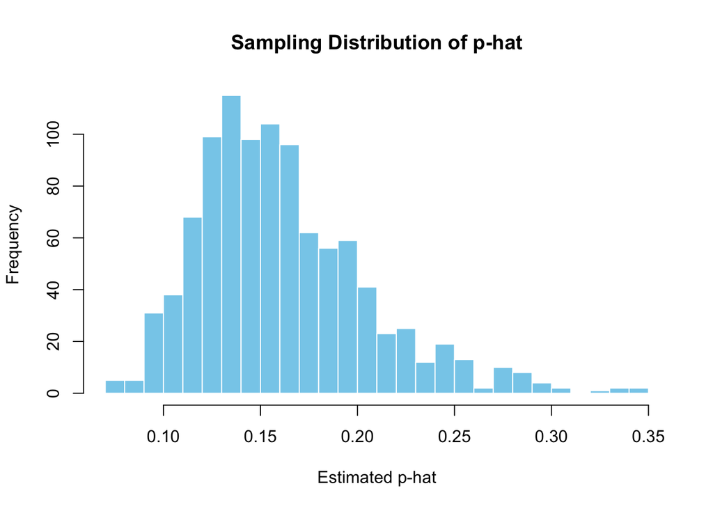

```r
# Set parameters
n <- 13              # Sample size
p_true <- 0.15       # True value of p
num_samples <- 1000  # Number of samples to simulate for the sampling distribution

# Generate sampling distribution
set.seed(123)  # For reproducibility
p_estimates <- replicate(num_samples, {
  sample_data <- rgeom(n, p_true)
  sample_mean <- mean(sample_data)
  p_hat <- 1 / (sample_mean + 1)
  return(p_hat)
})

# Plot histogram of the estimated sampling distribution
hist(p_estimates, breaks = 30, main = "Sampling Distribution of p-hat",
     xlab = "Estimated p-hat", col = "skyblue", border = "white")
```

3. Estimate the bias of this estimator. Is it biased? If it is biased how would you modify it so that you could create an unbiased estimator?

```r
# Set parameters
n <- 13              # Sample size
p_true <- 0.15       # True value of p
num_samples <- 1000  # Number of samples to simulate for the bias estimation

# Generate estimates of p_hat
set.seed(123)  # For reproducibility
p_estimates <- replicate(num_samples, {
  sample_data <- rgeom(n, p_true) + 1  # Adjust each sample by adding 1
  sample_mean <- mean(sample_data)
  p_hat <- 1 / sample_mean
  return(p_hat)
})

# Calculate the bias
mean_p_hat <- mean(p_estimates)
bias <- mean_p_hat - p_true

# Output the results
cat("Estimated Bias:", bias, "\n")
```

```
## Estimated Bias: 0.01136878
```

```r
cat("Is the estimator biased?", ifelse(abs(bias) > 1e-6, "Yes", "No"), "\n")
```

```
## Is the estimator biased? Yes
```

> If the estimator is biased, we could theoretically adjust it based on the expected bias. However, for a small sample size like n=13, a more sophisticated approach would involve calculating the exact expected bias analytically and adjusting accordingly. Alternatively, increasing the sample size n generally reduces bias in moment-based estimators, especially for distributions with high variance like the geometric distribution.

> Here is an example with a higher numbr of n:

```r
# Set parameters
n <- 200             # Sample size
p_true <- 0.15       # True value of p
num_samples <- 1000  # Number of samples to simulate for the bias estimation

# Generate estimates of p_hat
set.seed(123)  # For reproducibility
p_estimates <- replicate(num_samples, {
  sample_data <- rgeom(n, p_true) + 1  # Adjust each sample by adding 1
  sample_mean <- mean(sample_data)
  p_hat <- 1 / sample_mean
  return(p_hat)
})

# Calculate the bias
mean_p_hat <- mean(p_estimates)
bias <- mean_p_hat - p_true

# Output the results
cat("Estimated Bias:", bias, "\n")
```

```
## Estimated Bias: 0.0004774045
```

```r
cat("Is the estimator biased?", ifelse(abs(bias) > 1e-6, "Yes", "No"), "\n")
```

```
## Is the estimator biased? Yes
```

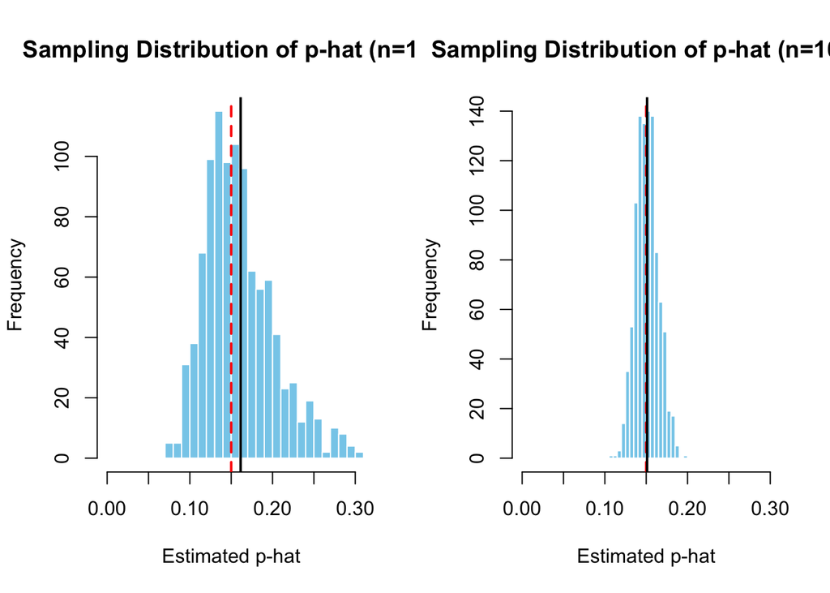

```r
# Set parameters
p_true <- 0.15       # True value of p
num_samples <- 1000  # Number of simulations for the sampling distribution

# Function to estimate p_hat for a given sample size
estimate_p_hat <- function(n) {
  replicate(num_samples, {
    sample_data <- rgeom(n, p_true) + 1  # Adjust each sample by adding 1
    sample_mean <- mean(sample_data)
    p_hat <- 1 / sample_mean
    return(p_hat)
  })
}

# Estimate p_hat for n = 13 and n = 100
set.seed(123)  # For reproducibility
p_estimates_13 <- estimate_p_hat(13)
p_estimates_100 <- estimate_p_hat(100)

# Calculate the mean of the estimates for both sample sizes
mean_estimates_13 <- mean(p_estimates_13)
mean_estimates_100 <- mean(p_estimates_100)

# Plot histograms with both true and estimated means
par(mfrow = c(1, 2))  # Set up side-by-side plotting

# Histogram for n = 13
hist(p_estimates_13, breaks = 30, main = "Sampling Distribution of p-hat (n=13)",
     xlab = "Estimated p-hat", col = "skyblue", border = "white", xlim = c(0, 0.3))
abline(v = p_true, col = "red", lwd = 2, lty = 2)  # True p line
abline(v = mean_estimates_13, col = "black", lwd = 2)  # Mean of estimates line

# Histogram for n = 100
hist(p_estimates_100, breaks = 30, main = "Sampling Distribution of p-hat (n=100)",
     xlab = "Estimated p-hat", col = "skyblue", border = "white", xlim = c(0, 0.3))
abline(v = p_true, col = "red", lwd = 2, lty = 2)  # True p line
abline(v = mean_estimates_100, col = "black", lwd = 2)  # Mean of estimates line
```

```r
# Adjusted estimator function
estimate_p_hat_adjusted <- function(n) {
  replicate(num_samples, {
    sample_data <- rgeom(n, p_true) + 1  # Adjust each sample by adding 1
    sample_mean <- mean(sample_data)
    p_hat_adjusted <- 1 / (sample_mean - 1/n)
    return(p_hat_adjusted)
  })
}

# Estimate adjusted p_hat for n = 13 and n = 100
set.seed(123)
p_estimates_adjusted_13 <- estimate_p_hat_adjusted(13)
p_estimates_adjusted_100 <- estimate_p_hat_adjusted(100)

# Calculate mean of adjusted estimates
mean_estimates_adjusted_13 <- mean(p_estimates_adjusted_13)
mean_estimates_adjusted_100 <- mean(p_estimates_adjusted_100)

# Compare bias in original vs. adjusted estimator for n = 13
cat("Original bias (n=13):", mean(p_estimates_13) - p_true, "\n")
```

```
## Original bias (n=13): 0.01136878
```

```r
cat("Adjusted bias (n=13):", mean_estimates_adjusted_13 - p_true, "\n")
```

```
## Adjusted bias (n=13): 0.01355101
```

```r
# Compare bias in original vs. adjusted estimator for n = 100
cat("Original bias (n=100):", mean(p_estimates_100) - p_true, "\n")
```

```
## Original bias (n=100): 0.001056049
```

```r
cat("Adjusted bias (n=100):", mean_estimates_adjusted_100 - p_true, "\n")
```

```
## Adjusted bias (n=100): 0.001286393
```

## Problem #3: Estimating $\lambda$ from a Poisson Distribution(8 pts; 2 pts each)

It is interesting that if $X\sim Pois(\lambda)$ that $EX=VarX=\lambda$. One could use either $\bar{X}$ or $S^2$ as an estimator of $\lambda$ perhaps.

1. Using $n=15$ and $\lambda=20$ for this problem, use MC simulation to estimate the sampling distribution of The estimator $\bar{X}$. Show its histogram.

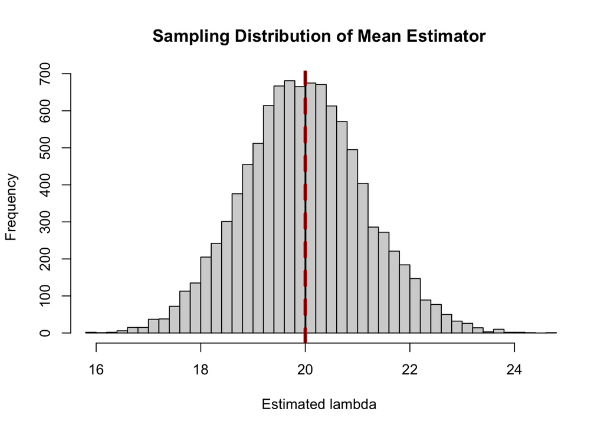

```r
set.seed(123)
n_samples <- 15
num_simulations <- 10000
lambda <- 20

# Function to generate a sample from Poisson(lambda) and calculate the sample mean
estimate_lambda_mean <- function(lambda, n) {
  samples <- rpois(n, lambda)
  sample_mean <- mean(samples)
  return(sample_mean)
}

# Generate estimates of lambda using the sample mean
estimates_mean <- replicate(num_simulations, estimate_lambda_mean(lambda, n_samples))
#estimates_mean
mean1<-mean(estimates_mean)

# Plot the histograms

hist(estimates_mean, breaks = 50, main = "Sampling Distribution of Mean Estimator", xlab = "Estimated lambda", xlim = c(min(estimates_mean), max(estimates_mean)))
abline(v = lambda, col = "red", lty=2,lwd = 4)
abline(v = mean1, col = "black", lwd = 2)
```

```r
cat(sprintf("True lambda: %f\n", lambda))
```

```
## True lambda: 20.000000
```

```r
cat(sprintf("Mean of estimated lambdas using mean: %f\n", mean1))
```

```
## Mean of estimated lambdas using mean: 20.002140
```

```r
cat(sprintf("Variance of estimated lambdas using mean: %f\n", var(estimates_mean)))
```

```
## Variance of estimated lambdas using mean: 1.359550
```

2. Repeat the same but this time use $S^2$.

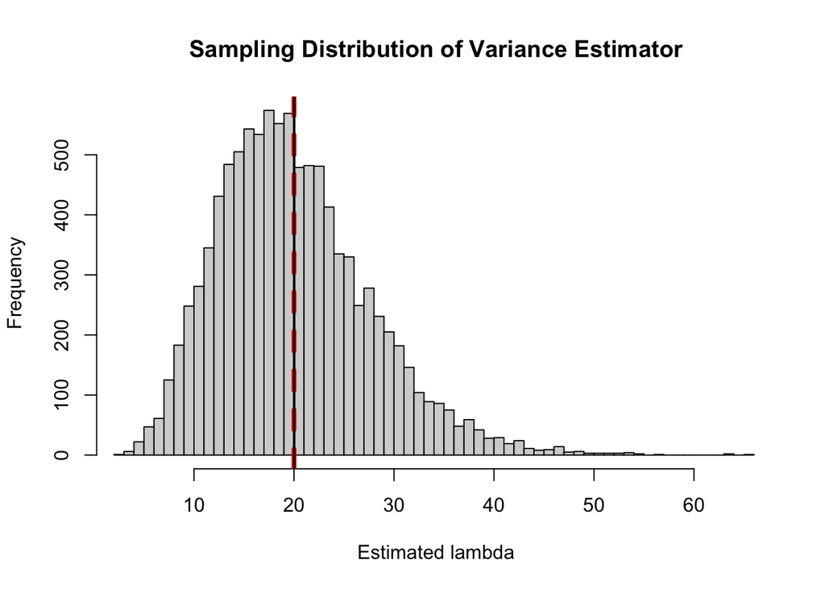

```r
set.seed(123)
n_samples <- 15
num_simulations <- 10000
lambda <- 20


# Function to generate a sample from Poisson(lambda) and calculate the sample variance
estimate_lambda_variance <- function(lambda, n) {
  samples <- rpois(n, lambda)
  sample_variance <- var(samples)
  return(sample_variance)
}

# Generate estimates of lambda using the sample variance
estimates_variance <- replicate(num_simulations, estimate_lambda_variance(lambda, n_samples))
#estimates_variance
mean2=mean(estimates_variance)
var2=var(estimates_variance)
# Plot the histograms

hist(estimates_variance, breaks = 50, main = "Sampling Distribution of Variance Estimator", xlab = "Estimated lambda", xlim = c(min(estimates_variance), max(estimates_variance)))
abline(v = lambda, col = "red",lty=2, lwd = 4)
abline(v = mean2, col = "black", lwd = 2)
```

```r
cat(sprintf("True lambda: %f\n", lambda))
```

```
## True lambda: 20.000000
```

```r
cat(sprintf("Mean of estimated lambdas using variance: %f\n", mean(estimates_variance)))
```

```
## Mean of estimated lambdas using variance: 20.020387
```

```r
# los rezultat
cat(sprintf("Variance of estimated lambdas using variance: %f\n", var(estimates_variance)))
```

```
## Variance of estimated lambdas using variance: 57.590833
```

3. Compare the two estimators. Would you prefer one over the other? Why?

> I would prefere mean1 which uses X_bar estimator. The sample mean of Xbar has a much lower variance than S^2, making it more stable as an estimator in this case.
4. What about a linear combination of the two variables? Could you construct an estimator of $\lambda$ of the form $a\bar{X} + bS^2$ that would be better than using either of them by themselves?

```r
set.seed(123)
n_samples <- 15
num_simulations <- 10000
lambda <- 20

# Function to generate a sample from Poisson(lambda) and calculate the combined estimator
estimate_combined <- function(lambda, n) {
  samples <- rpois(n, lambda)
  sample_mean <- mean(samples)
  sample_variance <- var(samples)
  combined_estimator <- 0.5 * sample_mean + 0.5 * sample_variance
  return(combined_estimator)
}

# Generate estimates of lambda using the combined estimator
estimates_combined <- replicate(num_simulations, estimate_combined(lambda, n_samples))
mean1
```

```
## [1] 20.00214
```

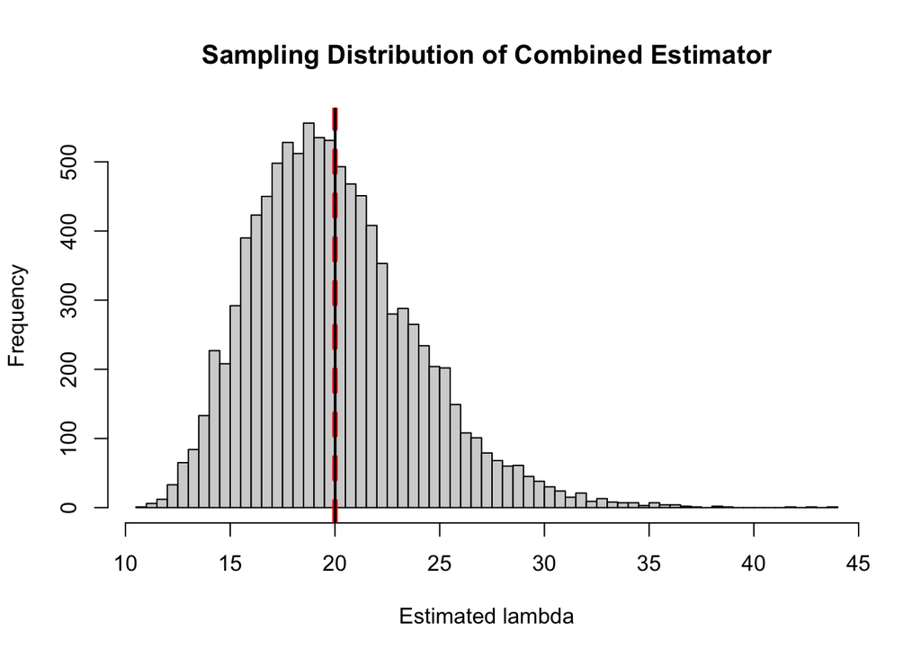

```r
# Plot the histogram
hist(estimates_combined, breaks = 50, main = "Sampling Distribution of Combined Estimator", xlab = "Estimated lambda")
abline(v = lambda, col = "red", lty=2,lwd = 4)
abline(v = mean(estimates_combined), col = "black", lwd = 2)
```

```r
cat(sprintf("True lambda: %f\n", lambda))
```

```
## True lambda: 20.000000
```

```r
cat(sprintf("Mean of combined estimator: %f\n", mean(estimates_combined)))
```

```
## Mean of combined estimator: 20.011263
```

```r
cat(sprintf("Variance of combined estimator: %f\n", var(estimates_combined)))
```

```
## Variance of combined estimator: 15.402482
```

> Conclusion: when we use combination of the two variables, we get better performance than S^2 but not better performance than X bar. The optimar ratio in aX_bar + bS^2 would be a=1 and b=0, which is the a) option.

## Problem #4: The Standard Error of $\bar{X}$(8 pts; 2 pts each)

What would be the required sample size $n$ so that the standard error of $\bar{X}$ (i.e. $SD(\bar{X})$) would be 2 (or just under 2) for the following populations:

> SE(X_hat) = sigma/sqrt(n) <= 2 -> (sigma/2)^2 <= n sigma^2/4 <= n var/4 <= n
1. $Normal(1000, 10^2)$

> n >= 100/4 = 25
2. $Pois(75)$

> n >= 75/4 ~= 19
3. $Binom(200, .35)$

> n >= 200 * 0.35 * 0.65 / 4 ~= 12
4. $exp(.05)$

> n >= 1/0.05^2 / 4 = 100